## 구조적 베이지안 시계열 방법(Bayesian Structural Time Series)[^1]

우리는 빅데이터, AI, 머신러닝을 사용하여 모델링을 하고 미래 예측값을 만들어 내는 과정은 대규모의 데이터를 활용해 다양한 알고리즘을 통한 관계를 도출하는 일련의 과정을 생각한다. 하지만 양이 작은 데이터를 활용하여 데이터를 분석하여 예측하는 것은 아직까지 크게 활성화되지 못한 분야임에 틀림 없다.

이 중 가장 대표적인 분야가 시계열 데이터 분석 분야일 것이다. 그렇지만 시계열 데이터 분석은 난이도가 높다고 알려진 까닭에 많이 활용되지는 못하지만 비지니스 상에서의 시계열 데이터의 폭넓은 활용은 이들 분석에 대한 필요성을 더욱 높이고 있다.

그동안 빈도주의 접근법을 사용하는 ARIMA등과 같은 모델이 시계열 모델링에 많이 사용됐지만 최근 베이지안 접근법이 많이 활용되면서 시계열 모델링에도 베이지안 접근법을 활용해서 모델을 구축하고 분석하는 방법들이 소개되고 있다.

이중 최근에 개발된 bsts(Bayesian Structural Time Series) 패키지를 사용해 베이지안 접근법을 활용해 시계열 데이터를 모델링하는 방법을 소개한다.

먼저 실습에 활용할 데이터로 년별 전체 학생수와 월별 전체 취업자 수 데이터를 로딩하겠다.

```r
students.all <- read_excel("./students.xlsx", skip = 16, na = '-', sheet = 1, col_types
                           = c('text', 'text', 'numeric', 'numeric', 'numeric', 'numeric', 'numeric', 'numeric', 'numeric', 'numeric', 'numeric', 'numeric', 'numeric', 'numeric', 'numeric','numeric', 'numeric', 'numeric'))

students <- students.all %>%
  filter(지역규모 == '계') %>% select(-지역규모)

students$연도 <- as.Date(paste0(students$연도, '-01-01'))

students.xts <- as.xts(students[,-1], order.by = students$연도)

employees <- read.csv('./산업별_취업자_20210206234505.csv', header = TRUE, na = '-', strip.white = TRUE, stringsAsFactors = TRUE)

colnames(employees) <- c('time', 'total', 'employees.edu')

employees$time <- as.Date(paste0(employees$time, '. 01'), format = '%Y. %m. %d')
```

### bsts 패키지 소개와 설치

bsts 패키지는 Predicting the Present with Bayesian Structural Time Series(Scott and Varian (2014)) 논문을 기반으로 구조적 베이지안 시계열 모델에 피팅(fitting)하기 위해 구글에서 제작해서 무료로 배포하는 오픈 소스 패키지이다. bsts는 시계열 모델 컴포넌트로 많이 사용되는 추세(trend), 계절성(seasonality) 뿐만아니라 서로 다른 시계열 데이터 간의 상관관계를 알아내서 반영하는 회귀 컴포넌트(regression)사용자에게 익숙한 구성 요소인 주기적 및 계절적 추세와 서로 다른 시계열 간의 상관 관계를 잡아내는 회귀 구성 요소로 조합 할 수 있다. 이 모델은 “구조적 시계열”, “상태 공간 모델”, “칼만 필터 모델”및 “동적 선형 모델”로 불리기도 한다.

bsts 패키지는 R CRAN에서 다운로드 가능하기 때문에 다음과 같이 설치할 수 있다.

```r
if (!require(bsts)) {
  install.packages('bsts')
  library(bsts)
}
```

### 구조적 시계열 모델(Structural Time Series Model)

구조적 시계열 모델은 관측 방정식과 전이 방정식으로 표현된다.

관측 방정식(observation equation)은 관측 데이터(observed data) $y_t$를 ’상태(state)’로 표현되는 잠재된 변수 $\alpha_t$로 표현한다. 방정식은 다음과 같이 표현된다.

$$y_t = Z_t^T\alpha_t + \epsilon_t$$

전이 방정식(transition equation)은 잠재 변수 $\alpha_t$가 시간에 따라 어떻게 변하는 지를 설명한다.

$$\alpha_{t+1} = T_t\alpha_t + R_t\eta_t$$

여기서 ARIAM나 다른 시계열 모델링에 표현되지 않았던 잠재된 변수라는 개념이 등장한다. 이 잠재 변수는 관찰되지 않은 추세(unobserved trend)이다. 예를 들어 잠재된 브랜드 가치의 성장이나 정밀하기 측정이 어려운 외부 요인들을 표현할 수 있다.

위의 두 방정식에서 오류를 나타내는 $\epsilon_t$과 $\eta_t$은 독립적 변수로 다른 변수의 영향을 받지 않고 정규분포하는 백색잡음이다. $Z_t$, $T_t$, $R_t$는 구조적 매개변수 배열을 의미한다. 따라서 관측방정식의 결과값 $Y_t$는 잠재변수 $\alpha_t$에 의해 결정되고 전이 방정식의 결과값 $\alpha_{t+1}$은 $\alpha_t$에 의해 결정된다.

이 방정식에서 $Z_t$, $T_t$, $R_t$를 모두 1로 설정하고 $\alpha_t$를 $\mu_t$로 치환해서 표현하면 다음과 같이 표현이 가능하다. 이 모델이 ’local level model’인데 노이즈에서 관찰되는 랜덤워크 모델로 가장 간단하지만 유용한 모델이다.

$$y_t = \mu_t + \epsilon_t$$
$$\mu_{t+1} = \mu_t + \eta_t$$

구조적 시계열 모델은 유연하고 모듈화되어 유용하다. 분석자는 단기 예측을 할 지, 장기 예츨을 할 지, 계절성이 포함되어 있는지 아닌지, 회귀 연산자를 포함하는지, 어떻게 포함하는지 등에 따라 $\alpha_t$를 결정할 수 있다.

만약 계절성과 회귀연산자를 모두 포함한다면 위의 방정식은 아래와 같이 변경될 수 있다.

$$Y_t = \mu_t + x_t\beta + S + \epsilon_t$$

여기서 $x_t$는 회귀자(regressor), $\beta$는 회귀계수, $S$는 계절성을 의미한다. $\mu_t$를 사용했기 때문에 결국 local level model을 기반으로 한다는 것을 나타낸다.

### 학생수 예측

```r
students.ss <- AddLocalLinearTrend(list(), students.xts[, 1])
```

먼저 시계열 데이터의 상태공간을 추가하기 위해 적절한 상태공간 함수를 호출한다. 앞서 기술한 바와 같이 전체 학생수 데이터는 연도 데이터이기 때문에 계절성이 없고 데이터에 특별한 회귀자가 없기 때문에 선형 트렌드을 상태공간 모델을 생성하는 `AddLocalLinearTrend()`를 사용한다. 여기서는 학생수의 xts 객체를 사용하였다.

```r
students.bayesian.model <- bsts(students.xts[, 1],
                                state.specification = students.ss,
                                niter = 1000)
```

[output not shown]

다음은 상태공간 모델을 사용하여 구조적 베이지안 시계열 모델을 생성한다. `bsts()`를 사용하여 구조적 베이지안 시계열 모델을 생성하는데 사용하는 시계열 데이터 원본은 `students.xts[,1]`이고 모델의 상태공간(`state.specification`)은 앞서 `AddLocalLinearTrend()`로 생성한 `students.ss`를 사용하고 MCMC(Marcov Chain Monte Carlo) 샘플 수를 1000회로 설정하였다.

```r
students.burn <- SuggestBurn(0.1, students.bayesian.model)
```

다음으로 MCMC에서 Burn-in으로 사용할 회수를 지정하는데 `SuggestBurn()`을 사용하고 비율을 0.1로 설정하였다.

```r
students.horizon.pred <- 5
```

예측을 시행할 기간을 지정하였는데 향후 5년간 데이터를 예측해보겠다.

```r
students.bayesian.pred <- predict.bsts(students.bayesian.model,
                                       horizon = students.horizon.pred,
                                       burn = students.burn,
                                       quantiles = c(.025, .975))
```

이제 앞서 생성한 구조적 베이지안 시계열 모델을 사용하여 예측치를 생성한다. 사용하는 함수는 `predict.bsts()`(그냥 `predict()`를 사용해도 가능하다.)를 사용한다.

이제는 예측값을 `ggplot2`를 사용하여 플롯팅해보자

```r
library(lubridate)
library(ggplot2)
students.bayesian.df <- data.frame(
  # fitted values and predictions
  c(time(students.xts[, 1]), seq(max(time(students.xts[, 1])) + years(1), by = 'years', length.out = students.horizon.pred)),
  c(as.numeric(students.xts[, 1]), rep(NA, students.horizon.pred)),
  c(as.numeric(-colMeans(students.bayesian.model$one.step.prediction.errors[-(1:students.burn),])+students.xts[, 1]),
    as.numeric(students.bayesian.pred$mean))
)

names(students.bayesian.df) <- c('Date', 'Actual', "Fitted")
```

위의 코드는 좀 복잡해 보인다. 위 코드의 최종 목표는 `students.bayesian.df` 데이터 프레임을 만드는 것인데 이 데이터 프레임은 Data, Actual, Fitted의 세개의 열을 가진다. 열의 이름에서 나타나 듯이 첫번째 열은 날짜(연도)를 나타내는 열이고 두번째 열은 실측값, 세번째 열은 `bsts()`를 사용하여 산출한 예측값을 나타낸다. 실측값이 기록된 2020년까지는 실측값과 적합값이 모두 존재하겠지만 실측값이 없는 2021년부터는 예측값만 기록될 것이다.

첫번째 열은 연도로 xts의 시간 인덱스 벡터를 반환하는 `time()`을 사용해 먼저 실측값이 있는 데이터 행의 연도를 산출한다. 여기에 추가적으로 `seq()`를 사용해서 연도를 추가해주는데 추가 예측년도의 시작년도는 `students.xts`의 연도의 최대값(`max()`)의 1년 후(`year(1)`) 부터 연도 단위(`by = 'year'`)로 예측값이 산출될 연도만큼(`students.horizon.pred`) 산출해준다.

두번째 열은 실측값을 넣어주는데 실측값이 없는 예측구간에는 `rep()`를 이용해 NA로 채워준다.

세번째 열은 적합값과 예측값을 넣어준다. `btst()`는 `fitted()`를 사용할 수 없기 떄문에 적합값을 직접 구해야 한다. `btst()`의 결과는 bsts 클래스인데 여기에는 원스텝 예측 오류값이 저장된다. 이 오류값은 MCMC 샘플수 만큼 생성되는데 이 오류값들의 평균값을 예측 오류값으로 볼 수 있다. 이 값을 실측값에서 빼주면 적합값이 산출된다. 여기에 `predict()`의 결과로 산출된 예측값을 추가한다.

```r
MAPE <- students.bayesian.df %>%
  filter(is.na(Actual) == F) %>%
  summarise(MAPE=mean(abs(Actual-Fitted)/Actual))
```

여기서는 성능측정 지수로 MAPE값을 산출하여 사용했다.

```r
students.bayesian.posterior.interval <- data.frame(
  filter(students.bayesian.df, is.na(Actual) == T)[, 1],
  students.bayesian.pred$interval[1,],
  students.bayesian.pred$interval[2,]
)

names(students.bayesian.posterior.interval) <- c("Date", "LL", "UL")
```

시계열 예측에는 예측구간을 표기하는 것이 바람직하다. 이를 표현하기 위한 추가적인 데이터 프레임을 생성한다. 예측구간은 `predict()`로 산출되는 결과 객체의 `interval` 열에 포함되어 있는데 `interval`의 첫번째 행은 lower bound, 두번째 행은 upper bound가 산출되어 있다.

```r
students.bayesian.df.pred <- left_join(students.bayesian.df, students.bayesian.posterior.interval, by="Date")
```

이제 앞서 만든 두개의 데이터 프레임을 날짜를 기준으로 조인해 준다.

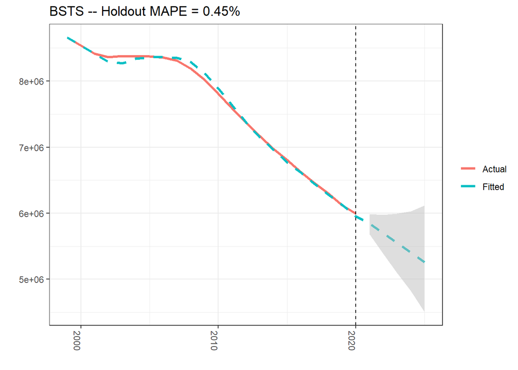

```r
students.bayesian.df.pred %>%
  ggplot(aes(x=Date)) +
  geom_line(aes(y=Actual, colour = "Actual"), size=1.2) +
  geom_line(aes(y=Fitted, colour = "Fitted"), size=1.2, linetype=2) +
  theme_bw() + theme(legend.title = element_blank()) + ylab("") + xlab("") +
  geom_vline(xintercept=as.numeric(as.Date("2020-01-01")), linetype=2) +
  geom_ribbon(aes(ymin=LL, ymax=UL), fill="grey", alpha=0.5) +
  ggtitle(paste0("BSTS -- Holdout MAPE = ", round(100*MAPE,2), "%")) +
  theme(axis.text.x=element_text(angle = -90, hjust = 0))
```

그리고 `ggplot2`를 사용해서 그려준다.

### 취업자수 예측

앞서 살펴본 학생수는 연도별 데이터이기 때문에 계절성이 없는 데이터였다. 이번에는 계절성을 가진 취업자수 데이터를 사용해 본다.

먼저 상태 공간을 설정해준다.

```r
employees.ss <- AddLocalLinearTrend(list(), employees$total)
employees.ss <- AddSeasonal(employees.ss, employees$total, nseasons = 12)
```

취업자 수는 추세와 계절성을 모두 가지는 데이터이기 때문에 먼저 추세 상태를 `AddLocalLinearTrend()`을 사용하여 추가하고 계절성을 `AddSeasonal()`을 사용하여 추가한다. 월별 데이터이므로 `nseasons`를 12로 설정한다.

```r
employees.bayesian.model <- bsts(employees$total,
                                state.specification = employees.ss,
                                niter = 1000)
```

[output not shown]

`bsts()`로 bayesian structural time series 모델을 만들어준다. MCMC 샘플수는 1000개로 설정한다.

```r
employees.burn <- SuggestBurn(0.1, employees.bayesian.model)

employees.horizon.pred <- 12
```

Burn in 수를 `SuggestBurn()`으로 산출하고 예측기간을 12로 설정한다.

```r
employees.bayesian.pred <- predict.bsts(employees.bayesian.model,
                                       horizon = employees.horizon.pred,
                                       burn = employees.burn,
                                       quantiles = c(.025, .975))
```

`predict()`를 사용하여 예측모델을 산출한다.

앞서 학생수에서 플롯을 그릴때 사용했던 것과 같은 방식으로 플롯을 그려준다.

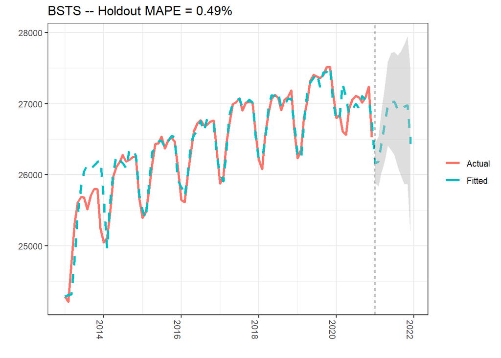

```r
employees.bayesian.df <- data.frame(
  c(employees$time, seq(max(employees$time) + months(1), by = 'month', length.out = employees.horizon.pred)),
  c(as.numeric(employees$total), rep(NA, employees.horizon.pred)),
  c(as.numeric(-colMeans(employees.bayesian.model$one.step.prediction.errors[-(1:employees.burn),])+employees$total),
    as.numeric(employees.bayesian.pred$mean))
)


names(employees.bayesian.df) <- c('Date', 'Actual', "Fitted")

MAPE <- employees.bayesian.df %>%
  filter(is.na(Actual) == F) %>%
  summarise(MAPE=mean(abs(Actual-Fitted)/Actual))


employees.bayesian.posterior.interval <- data.frame(
  filter(employees.bayesian.df, is.na(Actual) == T)[, 1],
  employees.bayesian.pred$interval[1,],
  employees.bayesian.pred$interval[2,]
)

names(employees.bayesian.posterior.interval) <- c("Date", "LL", "UL")

employees.bayesian.df.pred <- left_join(employees.bayesian.df, employees.bayesian.posterior.interval, by="Date")

employees.bayesian.df.pred %>%
  ggplot(aes(x=Date)) +
  geom_line(aes(y=Actual, colour = "Actual"), size=1.2) +
  geom_line(aes(y=Fitted, colour = "Fitted"), size=1.2, linetype=2) +
  theme_bw() + theme(legend.title = element_blank()) + ylab("") + xlab("") +
  geom_vline(xintercept=as.numeric(as.Date("2021-01-01")), linetype=2) +
  geom_ribbon(aes(ymin=LL, ymax=UL), fill="grey", alpha=0.5) +
  ggtitle(paste0("BSTS -- Holdout MAPE = ", round(100*MAPE,2), "%")) +
  theme(axis.text.x=element_text(angle = -90, hjust = 0))
```

[^1]: 영문을 그대로 번역하면 베이지안 구조적 시계열로 표기해야하나 아무리봐도 우리말에는 구조적 베이지안 시계열로 표현하는게 적절하다고 생각한다.